# Could Mortgages be Cheaper than Cash?

John Chavez

June 21, 2020

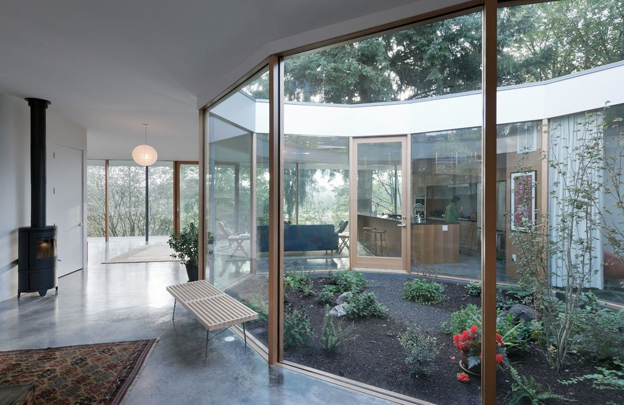

## Intro

Which is better: buying a house with cash or using a mortgage? Few people are lucky enough to pick between these two options, but the cheapest answer isn’t as clear-cut as you might expect.

Even if you had enough money to purchase a house without a loan, it’s possible that using a mortgage could be less expensive overall. The right choice depends on your mortgage’s interest rate and on what you do with your unused money.

In this post, I explore what would’ve happened if someone purchased a home in 1989 and placed all of their unused money in the S&P 500. I find that in this historical hypothetical, the homeowner would’ve been worse off using a mortgage than if they had just bought the house outright. However, under alternative hypotheticals with lower mortgage rates, it becomes cheaper to use a mortgage than purchasing the house straight away.

## Scenario

To investigate our hypothetical, we need to start off with some concrete numbers.

Let’s assume:

- You purchased a $2M home with a 20% ($400K) downpayment on January 1, 1989. (We choose ’89 because we can backtest a 30 year mortgage through 2019.)
- You invested whatever unspent money you had in the S&P 500.
- Every month, you withdrew the exact mortgage payment from your investment holdings.
- Your interest rate is 10%. (The 1989 average was 10.32%.)
- You locked in your interest rate in 1989 and never refinanced your mortgage.

To test this strategy, we need to know (a) how the stock market performed over the 30-year mortgage period (b) how much our mortgage would’ve cost.

### The Market

Let’s take a quick look at how the S&P 500 performed between 1989 and 2019.

```r
# Data from Yahoo Finance
# https://finance.yahoo.com/quote/%5EGSPC/history?period1=599616000&period2=1577836800&interval=1mo&filter=history&frequency=1mo

read.csv("sp500.csv") %>%
  mutate(Date = as.POSIXct(Date)) %>%
  subset(Date>='1989-01-01') %>%
  select(Date, Close) %>%
  rename(Price=Close) -> sp500

sp500 %$%
  xts(Price, Date) %>%
  dygraph() %>%
  dySeries("V1","S&P 500 Price")
```

[interactive chart not shown]

Just glancing at historical data for the S&P 500 can help you understand how this mortgage strategy could seem appealing. Between 1989 and 2019, the value of the S&P 500 exploded 986%.

```r
sp500 %$% first(Price) -> start
sp500 %$% last(Price) -> end
((end-start)/start * 100) %>% round(2) %>% paste(.,"%") %>% print()
```

```
## [1] "986.09 %"
```

It makes sense to expect that if you could take advantage of the massive long-term gains in the stock market, you could be better off investing your unused money and paying your mortgage payments as they come due. However, it all depends on how much you have to send to the bank each month.

### The Mortgage

Calculating monthly mortgage payments is relatively straightforward. All you need to know is your *p* (principal), *r* (interest rate), and *n* (number of payments). Once you have those, you can plug your numbers into this well-known formula:

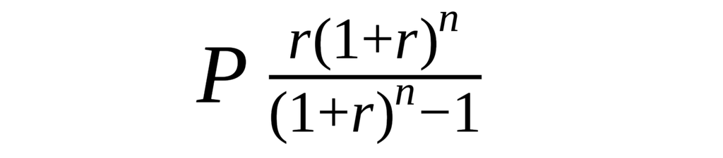

Let’s look at how our much our mortgage would cost each month.

```r
monthly_payment <- function(p,r,n){
  # The monthly mortgage payment formula
  p * (((r*(1+r)^n) / (((1+r)^n)-1)))
}

p <- 1600000 # principal
r <- .10/12 # monthly interest rate
n <- 30*12 # number of lifetime payments

monthly_payment(p,r,n) %>% round(2) %>% paste("$",.) %>% print()
```

```
## [1] "$ 14041.15"
```

Every single month you’ll get a bill for $14,041.15. The total amount of money you’ll have to give the bank for this $2M house will be over $5M. Herein lies the essential problem: mortgages are absolutely terrible.

```r
(monthly_payment(p,r,n)*30*12) %>% round(2) %>% paste("$",.) %>% print()
```

```
## [1] "$ 5054812.24"
```

Still, are the stock market’s gains enough to overcome the giant hole in your wallet that the mortgage will rip?

## Historical

Historically, no. The total amount of money you’ll end up losing, even with the sizable monthly increases in the S&P 500, is $3.83M. This is opposed to the $2M loss you’d incur if you’d simply bought the house with cash outright.

```r
sp500 %>%
  mutate(p = ifelse(!is.na(lag(Price)), 1 + ((Price - lag(Price)) / Price), 1),
         Outright=-2000000,
         Mortgage = Reduce(f = function(prev, i) (prev) * p[i] - 14041,
                           x = seq_along(Date), init = 1600000, acc = TRUE)[-1]) %>%
  select(Date, Mortgage, Outright) %>%
  read.zoo() %>%
  dygraph() %>%
  dyOptions(maxNumberWidth = 10)
```

[interactive chart not shown]

## Theoretical

We know that historically, this mortgage strategy would’ve failed. But does it always fail? It’s possible that in alternative realities (including the future), the mortgage could still be cheaper than cash. The two variables that determine this are (1) the mortgage’s interest rate (2) the stock market. We’ll investigate both of these.

First, would the mortgage be cheaper than buying outright at a different mortgage interest rate? We can run our simulation with 10 different interest rates:

```r
df <- sp500 %>%
  mutate(p = ifelse(!is.na(lag(Price)), 1 + ((Price - lag(Price)) / Price), 1), Outright=-2000000)

Outright <- df %$% xts(Outright, Date)
rates <- c(.05, .06, .07, .075, .08, .085, .09, .10, .11, .12)

run_sim <- function(df, r){
  m <- monthly_payment(1600000, r/12, 30*12)
  df %>% mutate(z = Reduce(f = function(prev, i) (prev) * p[i] - m, x = seq_along(Date), init = 1600000, acc = TRUE)[-1]) %>% select(z)
}

# Poor man's map
run_sim(df, rates) -> x
x <- do.call(rbind, x$z)
cbind(Outright, x) -> x

x %>%
  as.xts() %>%
  dygraph() %>%
  dyOptions(maxNumberWidth = 10) %>%
  dySeries("x","5%") %>% dySeries("x.1","6%") %>% dySeries("x.2","7%") %>% dySeries("x.3","7.5%") %>% dySeries("x.4","8%") %>% dySeries("x.5","8.5%") %>% dySeries("x.6","9%") %>% dySeries("x.7","10%") %>% dySeries("x.8","11%") %>% dySeries("x.9","12%")
```

[interactive chart not shown]

As you can see, if you got a mortgage with an interest rate below 8.5% in 1989, you would’ve saved money as compared to spending $2 million right off the bat. Slight changes in the mortgage interest rate can make a huge impact on the overall cost of the mortgage rate, as 30-year mortgages are compounded 360 times over their lifetime.

Now, what if the stock market was different?